# Attainment and Attendance in Lewes

What the national model behind *How to Pull the Right Lever* says about the district’s secondary schools, within East Sussex and alongside Brighton and Hove. **Draft for discussion.**

Author

Affiliation

Adam Dennett

Bartlett Centre for Advanced Spatial Analysis, University College London

Published

October 31, 2026

**WarningDraft for discussion**

One of the district documents for Sussex. It sits beneath the East Sussex document, and the district summary compares all of the districts. Every figure comes from published Department for Education data and the national models of [How to Pull the Right Lever](https://adamdennett.github.io/school_attainment_tool/pulling_the_right_lever_v2.html). Nothing uses pupil-level records. The commentary is written to a common pattern from the figures; read it as a starting point for discussion.

# Summary

**Lewes’s results are below the middle of England’s districts, on an intake less disadvantaged than England’s.** Its 6 state secondary schools are in Lewes, Newhaven, Peacehaven and Seaford.

- **Overall results:** 45.4 in Attainment 8 in 2024/25, 155th of 264 districts in England.
- **Disadvantage:** 21.5% of pupils are disadvantaged, against 28.3% nationally.
- **Disadvantaged pupils average 32.2**, below the national 37.8 (234th of 264).
- **The gap between disadvantaged pupils and the rest is 16.7 points**, the 21st widest of 264.

The other findings:

- **For all pupils, Lewes is 0.1 points below England.** The largest pieces in the national model are prior attainment (-1.6) and absence (-1.3). The district’s schools add 2.5 points beyond what the model expects.
- **For disadvantaged pupils it is 4.0 points below England.** The largest pieces are absence (-1.5) and being in the South East (-1.3), and the schools add 0.6 points beyond what the model expects.
- **A district effect on the published model disappears once each school’s own record is counted.** On the published model Lewes differs from the rest of East Sussex for all pupils (+4.4%) and non-disadvantaged pupils (+4.6%), but that difference belongs to particular schools, not to the place.
- **5 of the 6 schools are above expectation** over 2021/22 to 2024/25. The strongest is King’s Academy Ringmer (+5.3); the weakest Chailey School (-1.1).
- **Absence was 10.1%** in autumn and spring 2025/26 (9.7% a year earlier), against 8.0% for England and 8.9% for East Sussex. Over 2021/22 to 2024/25 its schools ran 0.2 points above what their intakes predict, and Seahaven Academy and Priory School more than a point above.
- **Reduced timetables run at 1.0 times the national rate, and suspensions at 0.9 times** (18.7 per 100 pupils, against 21.2).
- **Disadvantaged groups are small,** 18 to 50 pupils a year per school. Every school-level figure for them moves from year to year and should be read over several years.

# 1 About this analysis

Lewes is a district of East Sussex, not a local authority, and that shapes what can be said:

- **The national models place schools in local authorities.** The “local authority effect” in this document is East Sussex’s, shared with every school in the county.
- **What is particular to Lewes** shows up in its schools’ own residuals, and in the district test of Section 6.
- **Absence and exclusions** are summed over the district’s 6 schools, followed through any change of URN.

The methods are described in full in the East Sussex document.

# 2 The district’s schools

[interactive chart not shown]

Lewes’s state-funded secondary schools, coloured by overall absence in 2024/25. Choose another measure from the menu above the map; circle size is the school’s roll. Hover for figures and who runs each school.

Every state-funded secondary school in the district, 2024/25, with the size of its disadvantaged Year 11 group.

| School | Town | Type | Pupils | FSM % | Disadvantaged in Year 11 | Absence % | KS2 | Att 8 | Att 8 disadv. | Ofsted |
| --- | --- | --- | --- | --- | --- | --- | --- | --- | --- | --- |
| Chailey School | Lewes | Maintained | 855 | 10.7 | 18 | 6.8 | 5.6 | 49.2 | 36.2 | Good |
| King's Academy Ringmer | Lewes | Academy | 642 | 24.2 | 24 | 10.0 | 2.7 | 47.5 | 32.1 | Good |
| Priory School | Lewes | Maintained | 1163 | 20.9 | 47 | 12.1 | 5.3 | 46.3 | 25.5 | Good |
| Seahaven Academy | Newhaven | Academy | 745 | 30.2 | 42 | 12.6 | 1.7 | 40.2 | 32.4 | Good |
| Peacehaven Community School | Peacehaven | Academy | 903 | 28.7 | 50 | 11.2 | -0.1 | 39.7 | 28.8 | Good |
| Seaford Head School | Seaford | Academy | 1448 | 14.2 | 33 | 8.6 | 3.9 | 49.4 | 38.4 | Outstanding |

2 of the 6 schools are maintained by East Sussex County Council. The academies are run as follows:

- **King’s Academy Ringmer**, in King’s Group Academies;
- **Peacehaven Community School**, in Swale Academies Trust;
- **Seaford Head School**, in Seaford Learning Trust;
- **Seahaven Academy**, in United Learning Trust (sponsored);

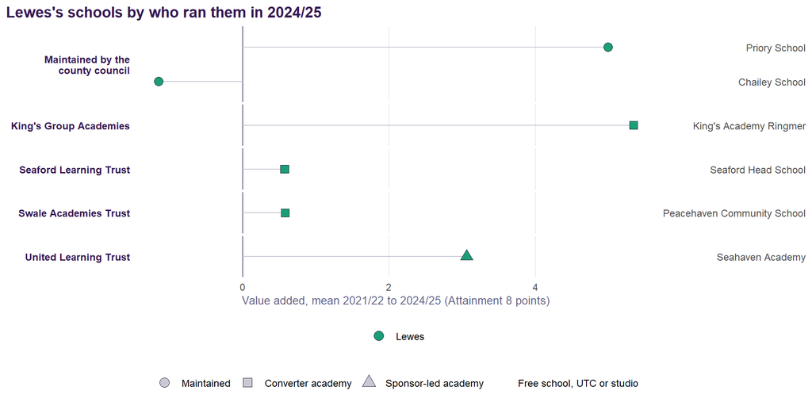

Figure 1: Who ran each school in 2024/25, and how far its results sat above or below the national model’s expectation over 2021/22 to 2024/25.

# 3 How Lewes compares

Lewes against East Sussex, Brighton and Hove and England, 2024/25. Means of school-level figures.

| Measure | Lewes | East Sussex | Brighton and Hove | England |
| --- | --- | --- | --- | --- |
| Attainment 8, all pupils | 45.4 | 43.8 | 45.5 | 46.8 |
| Attainment 8, disadvantaged | 32.2 | 33.0 | 33.9 | 37.7 |
| Attainment 8, non-disadvantaged | 49.0 | 47.5 | 49.6 | 49.9 |
| Disadvantage gap (points) | 16.7 | 14.5 | 15.7 | 12.2 |
| Disadvantaged (FSM6) % | 21.5 | 25.5 | 28.8 | 28.4 |
| Overall absence % | 10.2 | 9.7 | 11.3 | 8.6 |
| Persistent absence % | 26.5 | 26.4 | 30.6 | 23.9 |
| Mean KS2 (centred) | 3.18 | 3.79 | 4.71 | 4.47 |
| EAL % | 3.9 | 6.3 | 13.0 | 18.4 |

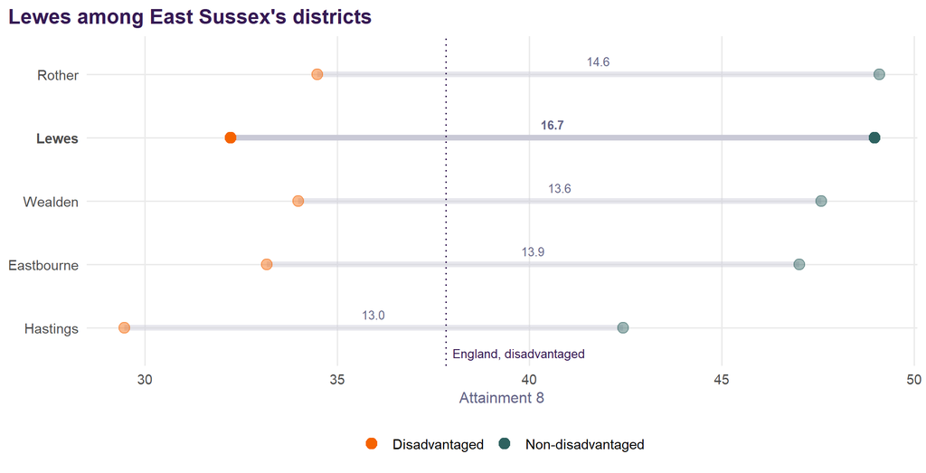

Figure 2: Attainment 8 for disadvantaged and non-disadvantaged pupils in East Sussex’s districts, 2024/25, school means. The gap between the two is printed on each district’s line; Lewes is in bold.

Across the years the model covers, the gap was 16.7 points in 2021/22 and 16.7 in 2024/25. Lewes’s non-disadvantaged pupils were above England’s average in 2 of 4 years, and its disadvantaged pupils in 0.

# 4 What explains attainment in Lewes

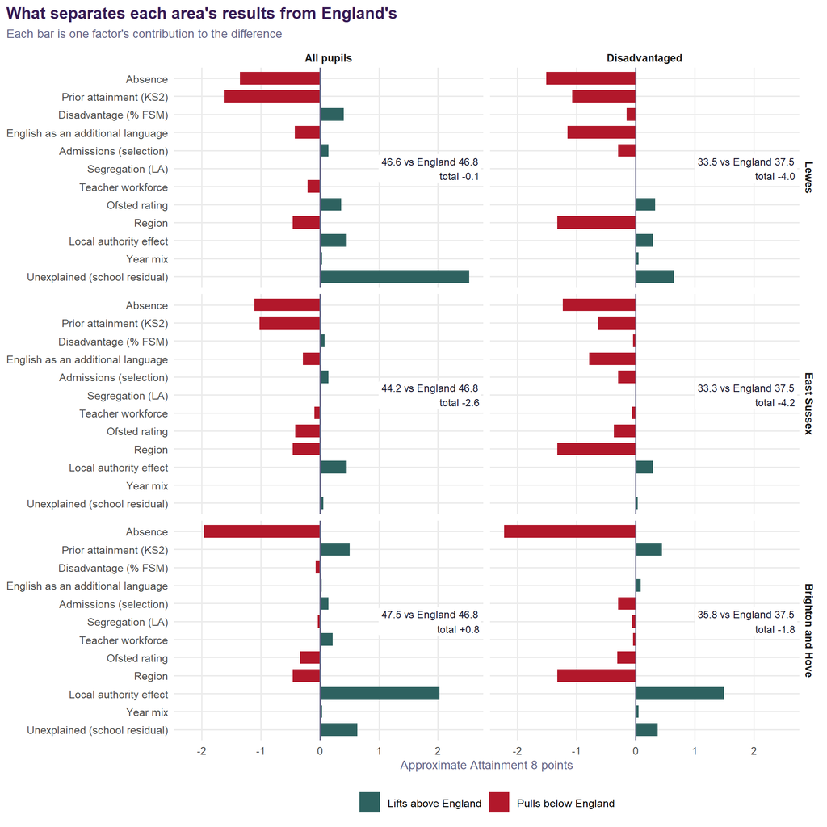

Figure 3: Why average Attainment 8 differs from England’s, by factor, all school-years 2021/22 to 2024/25, for Lewes, East Sussex and Brighton and Hove. Approximate Attainment 8 points; the pieces sum to the total in each panel.

The decomposition for Lewes, in Attainment 8 points. ‘Place’ is East Sussex’s effect plus the South East’s; ‘unexplained’ is what the district’s own schools add beyond everything the model accounts for.

| Factor | All pupils | Disadvantaged | Non-disadvantaged |
| --- | --- | --- | --- |
| Prior attainment (KS2) | -1.63 | -1.08 | -1.53 |
| Absence | -1.35 | -1.51 | -1.10 |
| English as an additional language | -0.42 | -1.15 | -0.61 |
| Teacher workforce | -0.20 | +0.00 | -0.19 |
| Place (region and local authority) | -0.00 | -1.03 | +0.28 |
| Other model terms | +0.19 | -0.25 | +0.16 |
| Ofsted rating | +0.36 | +0.33 | +0.33 |
| Disadvantage (% FSM) | +0.41 | -0.15 | +0.22 |
| Unexplained (school residual) | +2.53 | +0.65 | +2.52 |

**For all pupils**, Lewes is 0.1 points below England. The pieces of at least a quarter of a point:

- prior attainment (-1.63);
- absence (-1.35);
- being in the South East (-0.46);
- East Sussex’s county-wide effect (+0.46);
- English as an additional language (-0.42);
- the level of disadvantage (+0.41);
- Ofsted ratings (+0.36);
- and the district’s schools themselves (+2.53), beyond what the model expects.

**For disadvantaged pupils**, Lewes is 4.0 points below England. The pieces of at least a quarter of a point:

- absence (-1.51);
- being in the South East (-1.32);
- English as an additional language (-1.15);
- prior attainment (-1.08);
- Ofsted ratings (+0.33);
- admissions (-0.30);
- East Sussex’s county-wide effect (+0.29);
- and the district’s schools themselves (+0.65), beyond what the model expects.

# 5 The disadvantaged gap, school by school

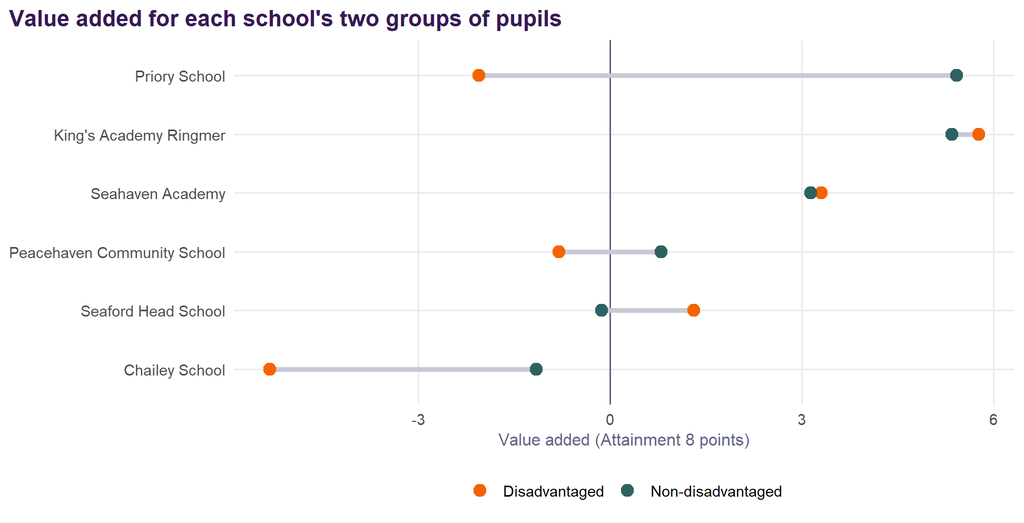

Figure 4: Each school’s value added for its disadvantaged and non-disadvantaged pupils, mean over the years available (2021/22 to provisional 2025/26). Above zero means better than the national model expects for similar pupils.

1 of the 6 schools is above expectation for non-disadvantaged pupils and more than a point below it for disadvantaged ones: Priory School. Seahaven Academy and King’s Academy Ringmer are above expectation for both groups. The table below gives each school’s own persistent effect, from the model with a school term, which is the steadier measure.

Table 1: Each school’s own persistent effect on the national model with a school term (%), for each group of pupils and for absence beyond what its intake predicts. Positive absence is worse.

| School | All pupils | Disadvantaged | Non-disadvantaged | Absence (stage 1) |
| --- | --- | --- | --- | --- |
| Chailey School | -0.6 | -8.9 | -1.4 | -16.1 |
| Priory School | +8.5 | -4.5 | +8.8 | +15.8 |
| Seaford Head School | +0.7 | +2.8 | -1.5 | -7.5 |
| Seahaven Academy | +5.2 | +8.6 | +2.6 | +32.5 |
| King's Academy Ringmer | +10.8 | +14.9 | +7.1 | -7.4 |
| Peacehaven Community School | +0.6 | -3.1 | +0.8 | -3.3 |

Table 2: Attainment 8 of each school’s disadvantaged pupils, year by year (2025/26 provisional), with the size of the group in 2024/25. Small groups make single years unreliable.

| School | 2021/22 | 2022/23 | 2023/24 | 2024/25 | 2025/26 | Disadvantaged pupils, 2024/25 |
| --- | --- | --- | --- | --- | --- | --- |
| Chailey School | 34.4 | 33.4 | 25.2 | 36.2 | 32.2 | 18 |
| King's Academy Ringmer | 36.8 | 42.6 | 41.7 | 32.1 | 34.8 | 24 |
| Peacehaven Community School | 32.9 | 25.6 | 28.2 | 28.8 | 32.4 | 50 |
| Priory School | 36.1 | 33.1 | 33.0 | 25.5 | 31.3 | 47 |
| Seaford Head School | 42.8 | 32.6 | 40.8 | 38.4 | 38.0 | 33 |
| Seahaven Academy | 35.3 | 33.3 | 32.6 | 32.4 | 32.0 | 42 |

# 6 Is there a Lewes effect?

The district test of the East Sussex document adds a district level to the national model, with and without each school’s own record.

Table 3: The Lewes district effect, over and above East Sussex’s, with 95% intervals.

| Specification | Outcome | Effect (%) | 95% interval | Significant |
| --- | --- | --- | --- | --- |
| Published specification | All pupils | +4.4 | +1.0 to +7.9 | Yes |
| Published specification | Disadvantaged | +1.6 | -2.4 to +5.7 | No |
| Published specification | Non-disadvantaged | +4.6 | +1.6 to +7.7 | Yes |
| Published specification | Absence (stage 1) | +0.6 | -6.3 to +8.0 | No |
| With a school term | All pupils | +1.6 | -1.6 to +5.0 | No |
| With a school term | Disadvantaged | +0.5 | -2.6 to +3.7 | No |
| With a school term | Non-disadvantaged | +2.5 | -0.8 to +6.1 | No |
| With a school term | Absence (stage 1) | +0.2 | -5.4 to +6.2 | No |

On the published model, Lewes differs from the rest of East Sussex for all pupils (+4.4%) and non-disadvantaged pupils (+4.6%). With each school’s own record in the model, none of that remains: the difference belongs to particular schools, not to the district as a place.

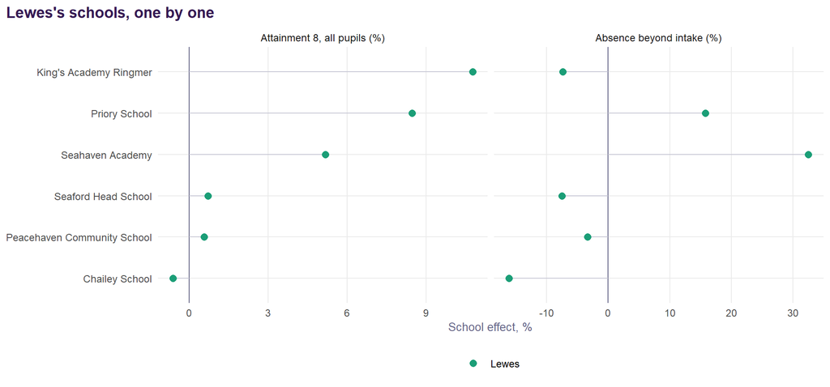

Figure 5: Each school’s own persistent effect, from the model with a school term: Attainment 8 for all pupils, and absence beyond what its intake predicts.

# 7 Absence

[figure not shown]

Figure 6: Overall absence, autumn and spring terms, 2016/17 to 2025/26. Sessions-weighted; 2019/20 not collected.

- **10.1% absence** in autumn and spring 2025/26, against 8.0% for England and 8.9% for East Sussex. A year earlier it was 9.7%.
- **Persistent absence** is 25.9%, against 21.6% for England.
- **Against its intake**, the district’s schools run 0.24 points above what their pupils’ profiles predict, on average over 2021/22 to 2024/25.

Table 4: Each school’s absence against what its intake predicts, mean 2021/22 to 2024/25, and its reasons in the latest year (percentage of sessions).

| School | Absence % | Predicted by intake % | Above prediction | Illness | Unauthorised | Reduced timetable | Suspended |
| --- | --- | --- | --- | --- | --- | --- | --- |
| Seahaven Academy | 13.9 | 10.5 | +3.4 | 4.6 | 5.0 | 0.68 | 0.69 |
| Priory School | 10.9 | 9.1 | +1.7 | 6.8 | 3.2 | 0.17 | 0.30 |
| Seaford Head School | 8.4 | 8.9 | -0.5 | 4.8 | 3.0 | 0.24 | 0.01 |
| Peacehaven Community School | 10.5 | 11.4 | -0.8 | 4.6 | 3.1 | 0.24 | 0.17 |
| King's Academy Ringmer | 9.7 | 10.8 | -1.1 | 5.8 | 1.7 | 0.25 | 0.55 |
| Chailey School | 7.4 | 8.6 | -1.2 | 3.8 | 2.0 | 0.39 | 0.10 |

- **Seahaven Academy and Priory School** each run more than a point above their predicted absence.
- **Chailey School and King’s Academy Ringmer** run more than a point below their predictions.

Reduced timetables account for 0.30% of sessions, against 0.29% in England, 1.0 times the national rate. Seahaven Academy’s rate is the highest in the district.

Table 5: Predicted Attainment 8 gain if each school’s absence fell to the national school average (2024/25). Indicative only.

| School | District | Absence % | FSM % | Gain, all pupils | Gain, disadvantaged | Gain from FSM to area average |
| --- | --- | --- | --- | --- | --- | --- |
| Priory School | Lewes | 12.1 | 20.9 | +3.4 | +2.7 | +0.0 |
| Seahaven Academy | Lewes | 12.6 | 30.2 | +3.4 | +4.0 | +0.7 |
| Peacehaven Community School | Lewes | 11.2 | 28.7 | +2.3 | +2.4 | +0.6 |
| King's Academy Ringmer | Lewes | 10.0 | 24.2 | +1.5 | +1.5 | +0.3 |
| Seaford Head School | Lewes | 8.6 | 14.2 | +0.1 | +0.1 | +0.0 |

5 of the 6 schools are above the national average absence in 2024/25. Bringing them to it would add up to 3.4 points for all pupils, as an indication of scale.

**Suspensions** were 18.7 per 100 pupils in 2024/25, against 21.2 for England and 28.0 for East Sussex.

Table 6: Suspensions per 100 pupils and permanent exclusions, by school, latest year.

| School | Pupils | Suspensions per 100 | Permanent exclusions |
| --- | --- | --- | --- |
| Seahaven Academy | 745 | 47.9 | 4 |
| King's Academy Ringmer | 642 | 32.7 | 4 |
| Priory School | 1163 | 22.5 | 0 |
| Peacehaven Community School | 903 | 13.8 | 1 |
| Chailey School | 855 | 12.2 | 0 |
| Seaford Head School | 1448 | 1.5 | 0 |

# 8 Contextual league tables

**All pupils**

Value added, all pupils: observed Attainment 8 minus the national model’s expectation. 2025/26 is provisional.

| School | 2021/22 | 2022/23 | 2023/24 | 2024/25 | 2025/26 | Mean | Years |
| --- | --- | --- | --- | --- | --- | --- | --- |
| King's Academy Ringmer | +5.8 | +4.5 | +4.5 | +5.8 | +7.9 | +5.7 | 5 |
| Priory School | +5.8 | +4.6 | +7.4 | +1.6 | +2.5 | +4.4 | 5 |
| Seahaven Academy | +5.2 | +2.6 | +1.8 | +2.2 | +4.4 | +3.2 | 5 |
| Seaford Head School | -0.6 | +0.0 | +1.9 | +0.5 | +0.6 | +0.5 | 5 |
| Peacehaven Community School | -1.5 | -1.4 | +2.3 | +2.6 | -0.3 | +0.4 | 5 |
| Chailey School | -2.9 | -2.3 | +3.1 | -3.2 | -1.7 | -1.4 | 5 |

**Disadvantaged pupils**

Value added, disadvantaged pupils. Small groups; read across years.

| School | 2021/22 | 2022/23 | 2023/24 | 2024/25 | 2025/26 | Mean | Years |
| --- | --- | --- | --- | --- | --- | --- | --- |
| King's Academy Ringmer | +4.5 | +10.6 | +10.2 | +0.6 | +2.9 | +5.8 | 5 |
| Seahaven Academy | +2.7 | +4.7 | +4.0 | +3.2 | +1.9 | +3.3 | 5 |
| Seaford Head School | +1.2 | -3.4 | +4.8 | +2.3 | +1.6 | +1.3 | 5 |
| Peacehaven Community School | -1.2 | -5.0 | -1.0 | +0.6 | +2.6 | -0.8 | 5 |
| Priory School | -1.2 | -0.9 | +0.1 | -6.6 | -1.7 | -2.1 | 5 |
| Chailey School | -6.5 | -2.2 | -10.7 | -1.6 | -5.6 | -5.3 | 5 |

**Non-disadvantaged pupils**

Value added, non-disadvantaged pupils.

| School | 2021/22 | 2022/23 | 2023/24 | 2024/25 | 2025/26 | Mean | Years |
| --- | --- | --- | --- | --- | --- | --- | --- |
| Priory School | +7.1 | +5.7 | +8.3 | +3.4 | +2.5 | +5.4 | 5 |
| King's Academy Ringmer | +6.0 | +2.7 | +2.6 | +7.3 | +8.2 | +5.4 | 5 |
| Seahaven Academy | +6.3 | +1.8 | +0.6 | +1.5 | +5.5 | +3.1 | 5 |
| Peacehaven Community School | -1.6 | +0.4 | +3.5 | +3.3 | -1.6 | +0.8 | 5 |
| Seaford Head School | -1.0 | +0.0 | +0.8 | -0.6 | +0.1 | -0.1 | 5 |
| Chailey School | -2.5 | -2.7 | +4.4 | -3.6 | -1.4 | -1.2 | 5 |

# 9 Questions for discussion

1. **Disadvantaged pupils.** They average 32.2 in Lewes against 37.8 in England, and the district’s schools add 0.6 points for them beyond what the model expects. What do King’s Academy Ringmer and Seahaven Academy, above expectation for these pupils, do that the district’s other schools could share?
2. **Attendance is a lever here.** Absence costs the district 1.3 points against England for all pupils, and Seahaven Academy and Priory School run more than a point above what their intakes predict.
3. **Schools, not the place.** The district’s apparent effect belongs to particular schools; the question is what is happening in them.
4. **Practice.** Reduced timetables and suspensions are close to or below the national rate.
5. **The county.** East Sussex’s own effect for disadvantaged pupils is +0.9% (60th of 151), not distinguishable from zero. The county questions in the East Sussex document apply here as well.

# Notes on method

Methods and sources are those of the East Sussex document. District membership comes from each school’s postcode (ONS postcode directory, via postcodes.io). Absence and exclusions for the district are summed over its schools, including any predecessor or successor URNs. This document is generated from `templates/district_report.qmd` by `R/20_district_reports.R`, from data built by `R/17_area_analysis.R`, `R/18_district_effects.R` and `R/19_trust_effects.R`. Its format is described in `AREA_REPORTS.md`.